# Assignment 9 Report

First, I loaded the following packages to set up for my analysis

```r
library(tidyverse)
library(caret)
library(broom)
library(modelr)
library(easystats)
library(janitor)
library(skimr)
```

Next, I loaded the data and took a quick look at the structure.

```r
df <- read_csv("./GradSchool_Admissions.csv")
str(df)
```

```
## spc_tbl_ [400 × 4] (S3: spec_tbl_df/tbl_df/tbl/data.frame)
##  $ admit: num [1:400] 0 1 1 1 0 1 1 0 1 0 ...
##  $ gre  : num [1:400] 380 660 800 640 520 760 560 400 540 700 ...
##  $ gpa  : num [1:400] 3.61 3.67 4 3.19 2.93 3 2.98 3.08 3.39 3.92 ...
##  $ rank : num [1:400] 3 3 1 4 4 2 1 2 3 2 ...
##  - attr(*, "spec")=
##   .. cols(
##   ..   admit = col_double(),
##   ..   gre = col_double(),
##   ..   gpa = col_double(),
##   ..   rank = col_double()
##   .. )
##  - attr(*, "problems")=<externalptr>
```

I then wanted to change the admit column from a numeric variable to a logical variable, and assigned this change to the df over itself. This change will allow me to run logistic regressions on the data.

```r
df <- df %>%
  mutate(admit = case_when (admit == 1 ~ TRUE,
                            TRUE ~ FALSE))
```

Now that the data is loaded and cleaned, I’ll make a few models investigating the effects of the different variables on acceptance.

```r
names(df)
```

```
## [1] "admit" "gre"   "gpa"   "rank"
```

```r
mod1 <- glm(data = df, formula = admit ~ rank, family = 'binomial')

mod2 <- glm(data = df, formula = admit ~ gpa, family = 'binomial')

mod3 <- glm(data = df, formula = admit ~ gre, family = 'binomial')

mod4 <- glm(data = df, formula = admit ~ gpa * gre, family = 'binomial') # personal interest in the interaction between gpa and gre

full_mod <- glm(data = df, formula = admit ~ gpa * gre * rank, family = 'binomial')
```

Then I compared these models and their performance

```r
compare_models(mod1, mod2, mod3, mod4, full_mod)
```

```
## Parameter          |                 mod1 |                 mod2 |                    mod3 |                      mod4 |                  full_mod
## --------------------------------------------------------------------------------------------------------------------------------------------------
## (Intercept)        |  0.64 ( 0.04,  1.24) | -4.36 (-6.39, -2.33) |    -2.90 (-4.09, -1.71) |    -13.82 (-25.33, -2.30) |    -15.08 (-47.25, 17.09)
## rank               | -0.59 (-0.83, -0.34) |                      |                         |                           |      0.05 (-12.90, 13.00)
## gpa                |                      |  1.05 ( 0.47,  1.64) |                         |      3.37 ( -0.01,  6.74) |      4.36 ( -5.14, 13.86)
## gre                |                      |                      | 3.58e-03 ( 0.00,  0.01) |      0.02 ( -0.00,  0.04) |      0.02 ( -0.03,  0.07)
## gpa × gre          |                      |                      |                         | -4.33e-03 ( -0.01,  0.00) | -5.10e-03 ( -0.02,  0.01)
## gpa × rank         |                      |                      |                         |                           |     -0.24 ( -4.03,  3.55)
## gre × rank         |                      |                      |                         |                           |  2.15e-04 ( -0.02,  0.02)
## (gpa × gre) × rank |                      |                      |                         |                           |  4.18e-05 ( -0.01,  0.01)
## --------------------------------------------------------------------------------------------------------------------------------------------------
## Observations       |                  400 |                  400 |                     400 |                       400 |                       400
```

```r
compare_performance(mod1, mod2, mod3, mod4, full_mod)
```

```
## # Comparison of Model Performance Indices
##
## Name     | Model | AIC (weights) | AICc (weights) | BIC (weights) | Tjur's R2 |  RMSE | Sigma | Log_loss | Score_log | Score_spherical |   PCP
## ----------------------------------------------------------------------------------------------------------------------------------------------
## mod1     |   glm | 479.7 (0.023) |  479.7 (0.028) | 487.7 (0.990) |     0.060 | 0.451 | 1.000 |    0.595 |   -49.032 |           0.010 | 0.593
## mod2     |   glm | 491.0 (<.001) |  491.0 (<.001) | 499.0 (0.004) |     0.032 | 0.458 | 1.000 |    0.609 |   -48.163 |           0.004 | 0.581
## mod3     |   glm | 490.1 (<.001) |  490.1 (<.001) | 498.0 (0.006) |     0.034 | 0.458 | 1.000 |    0.608 |   -48.247 |           0.003 | 0.581
## mod4     |   glm | 485.8 (0.001) |  486.0 (0.001) | 501.8 (<.001) |     0.052 | 0.453 | 1.000 |    0.597 |   -48.633 |           0.004 | 0.589
## full_mod |   glm | 472.2 (0.975) |  472.6 (0.971) | 504.2 (<.001) |     0.106 | 0.440 | 1.000 |    0.570 |   -50.593 |           0.005 | 0.613
```

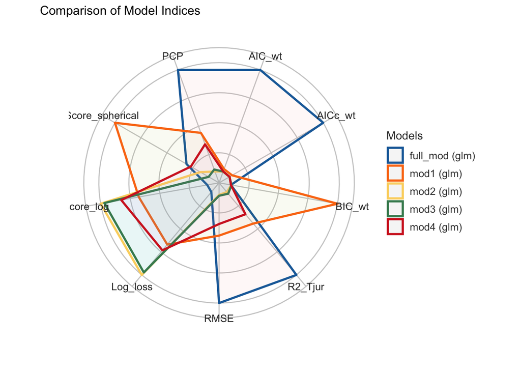

```r
compare_performance(mod1, mod2, mod3, mod4, full_mod) %>% plot
```

From comparing performance, we can see that full_mod has the smallest RMSE  
I then used the stepAIC function from the MASS package to optimize full_mod and see if there was a better way to structure it.

```r
step <- MASS::stepAIC(full_mod, trace = 0)
step$formula
```

```
## admit ~ gpa + gre + rank + gpa:gre
```

I used the formula output above to create a new model (mod5), and then compared it to all of the other models

```r
mod5 <- glm(data = df, formula = admit ~ gpa + gre + rank + gpa:gre, family = 'binomial')
compare_performance(mod1, mod2, mod3, mod4, full_mod, mod5, rank = TRUE)
```

```
## Following indices with missing values are not used for ranking: Sigma
```

```
## # Comparison of Model Performance Indices
##
## Name     | Model | Tjur's R2 |  RMSE | Sigma | Log_loss | Score_log | Score_spherical |   PCP | AIC weights | AICc weights | BIC weights | Performance-Score
## ------------------------------------------------------------------------------------------------------------------------------------------------------------
## mod5     |   glm |     0.105 | 0.440 | 1.000 |    0.571 |   -50.481 |           0.004 | 0.612 |       0.943 |        0.948 |       0.636 |            68.21%
## mod1     |   glm |     0.060 | 0.451 | 1.000 |    0.595 |   -49.032 |           0.010 | 0.593 |       0.001 |        0.001 |       0.360 |            44.24%
## full_mod |   glm |     0.106 | 0.440 | 1.000 |    0.570 |   -50.593 |           0.005 | 0.613 |       0.056 |        0.050 |    9.46e-05 |            37.21%
## mod4     |   glm |     0.052 | 0.453 | 1.000 |    0.597 |   -48.633 |           0.004 | 0.589 |    6.22e-05 |     6.42e-05 |    3.09e-04 |            27.83%
## mod2     |   glm |     0.032 | 0.458 | 1.000 |    0.609 |   -48.163 |           0.004 | 0.581 |    4.81e-06 |     5.15e-06 |       0.001 |            23.22%
## mod3     |   glm |     0.034 | 0.458 | 1.000 |    0.608 |   -48.247 |           0.003 | 0.581 |    7.59e-06 |     8.12e-06 |       0.002 |            22.08%
```

```
## Following indices with missing values are not used for ranking: Sigma
```

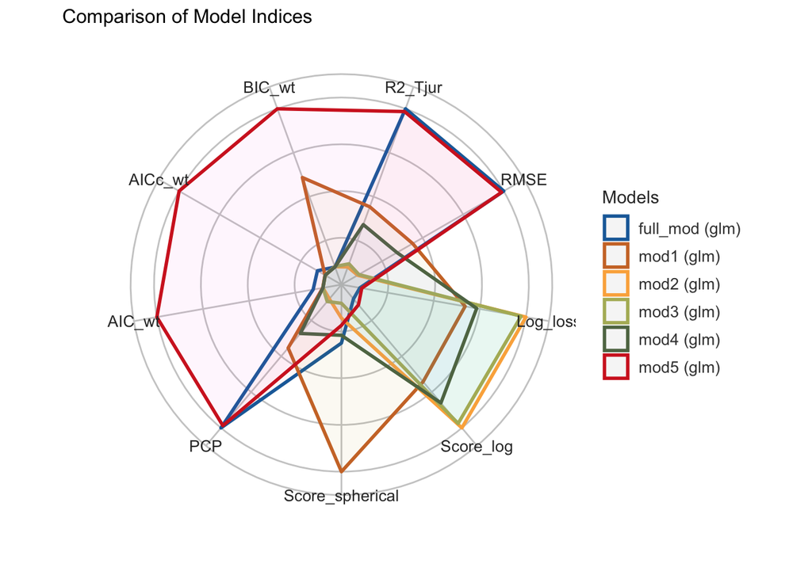

```r
compare_performance(mod1, mod2, mod3, mod4, full_mod, mod5, rank = TRUE) %>% plot
```

We can see from this output that mod5 is the best model.  
Next, I generated predictions by mod5 and saved them in a new column in df called “mod5pred”

```r
df$mod5pred <- predict(mod5, df, type = 'response')
```

Finally, I plotted the predictions made by mod5 alongside the original data.

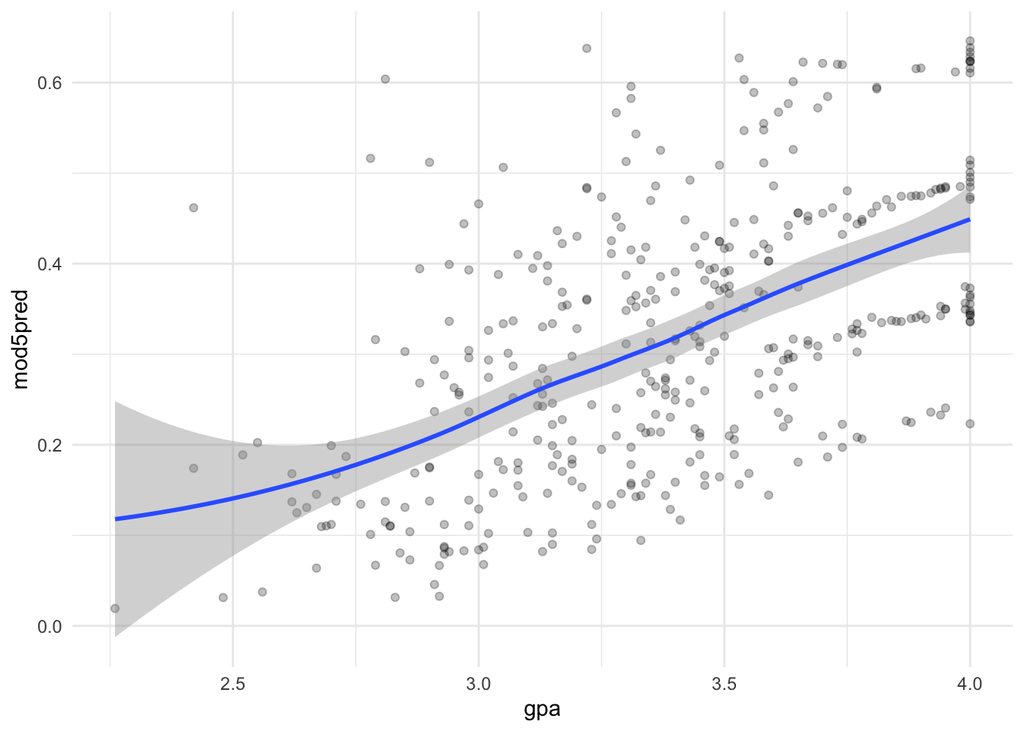

```r
df %>%
  ggplot(aes(x=gpa, y = mod5pred))+
  geom_point(alpha = 0.25)+
  geom_smooth()+
  theme_minimal()
```